# Progetto di Fondamenti di Scienze dei Dati e lab.

27/9/2023

## Parte 1

- Nella storia della Formula 1 la costanza è stata più importante delle vittorie?
- Per rispondere a questa prima domanda conteremo quante volte un pilota ha vinto un titolo di F1 senza ottenere il maggior numero di vittorie.
- Ma prima, ci chiediamo quante volte sia successo questo in 73 stagioni di F1.

## First plot

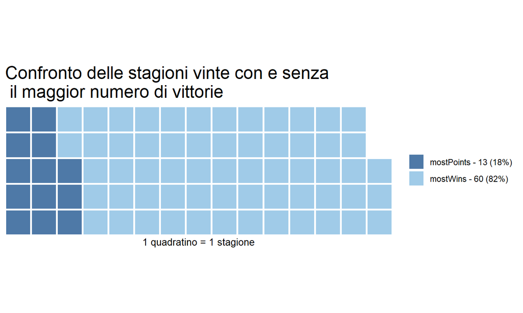

## Second plot

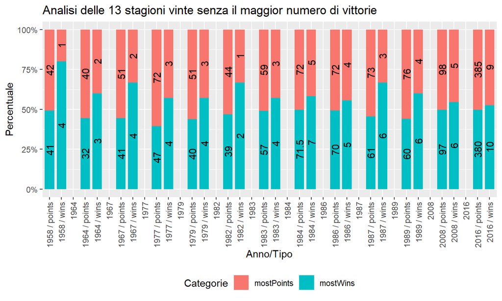

## Fun fact 1

- Nella stagione del 1984, ci fu un duello memorabile tra i piloti della McLaren Alain Prost e Niki Lauda.
- Prost ha vinto sette gare contro le cinque di Lauda, comprese le ultime due gare della stagione, ma alla fine Lauda ha avuto la meglio per mezzo punto; il margine più piccolo nella storia della Formula Uno.
- Era il terzo titolo di Lauda, il primo dopo il 1977.
- La McLaren vinse il Campionato Costruttori dopo ben 10 anni.

## Conclusione 1

- Vincere nella F1 è generalmente importante perché l’82% delle volte ottenere il maggior numero di vittorie ha portato alla vittoria del titolo.
- Infatti, in media vincere un titolo senza aver ottenuto il maggior numero di vittorie avviene solo 1 volta ogni 5 stagioni e mezzo.

## Parte 2

- Se vincere è così importante in F1, quanto è importante partire davanti alla griglia per salire sul gradino più alto del podio?
- Per rispondere a questa seconda domanda conteremo le vittorie in base alla posizione iniziale di partenza.
- Qual è la percentuale di vittorie che ci aspettiamo partendo dalla pole position?

## First plot

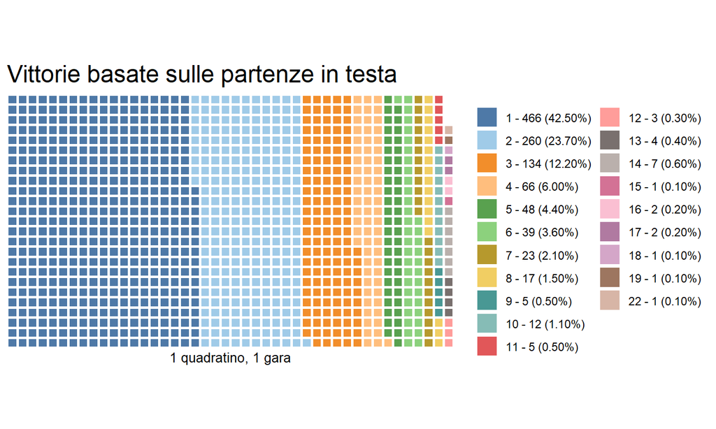

## Second plot

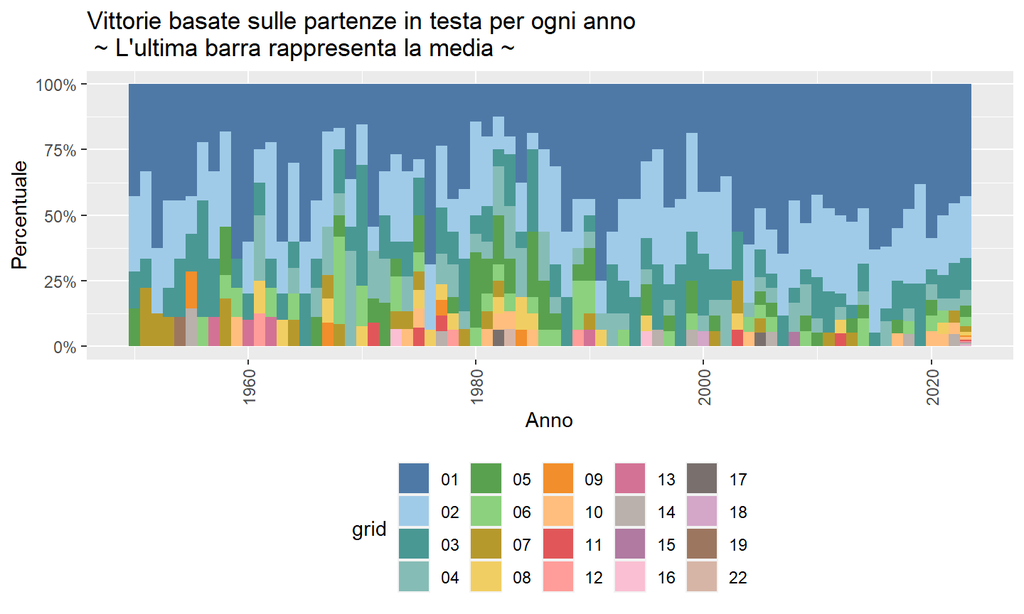

## Fun fact 2

- Il record per la vittoria nella F1 conseguita dopo la partenza più arretrata nella griglia, spetta a John Watson, partito 22esimo nella United States Grand Prix West del 1983, con McLaren.
- Conseguì così il suo quinto ed ultimo titolo nel mondiale.
- Il suo compagno di squadra, Niki Lauda, che arrivò secondo, partì invece dalla 23esima posizione.

## Conclusione 2

- Nella storia della F1 la partenza dalla pole è stata solitamente molto importante poiché in media ha portato a oltre il 40% delle vittorie.
- Il secondo posto, invece, ha portato a quasi ¼ delle vittorie e il terzo solo a circa ⅛ delle vittorie.
- Sotto il terzo posto le percentuali scendono sotto il 10%.

## Parte 3

- Ora che sappiamo come è correlata la posizione di partenza alla probabilità di ottenere una vittoria, quanto sono diverse le percentuali a Monaco, che è un classico circuito cittadino che di solito non offre molti sorpassi?
- Per rispondere a questa domanda finale utilizzeremo lo stesso processo di prima ma concentrandoci sulla differenza tra la media di tutti i circuiti e il GP di Monaco.
- Qual è la percentuale di vittorie che vi aspettate questa volta partendo dalla pole position ricordando che in media è del 42,50%?

## Plot

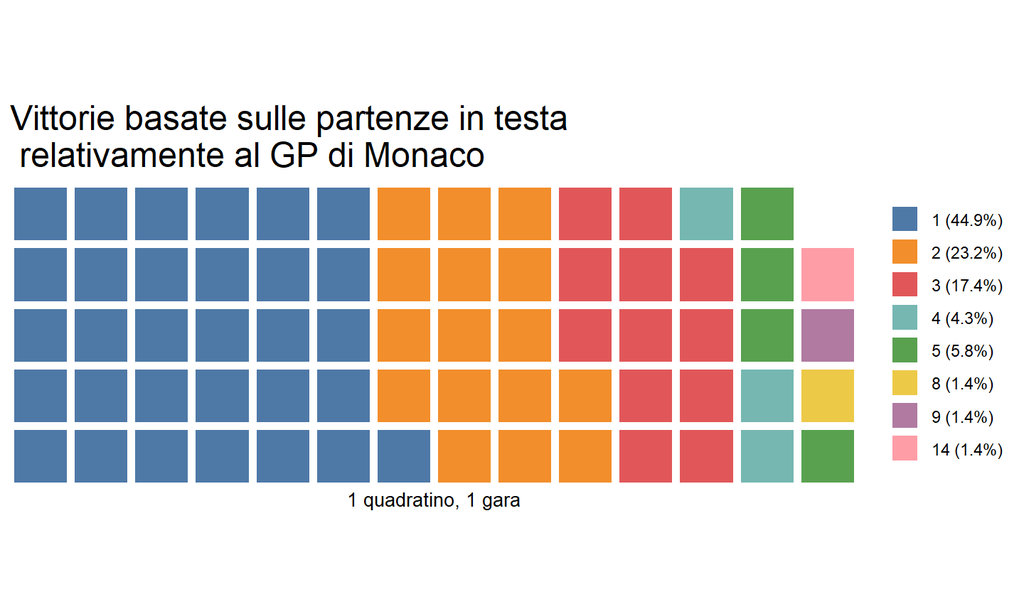